# Assignment 3 - Part 2 - Diagnosing Schizophrenia from Voice

Riccardo Fusaroli

October 17, 2017

## Assignment 3 - Part 2 - Diagnosing schizophrenia from voice

In the previous part of the assignment you generated a bunch of “features”, that is, of quantitative descriptors of voice in schizophrenia. We then looked at whether we could replicate results from the previous literature. We now want to know whether we can automatically diagnose schizophrenia from voice only, that is, relying on the set of features you produced last time, we will try to produce an automated classifier. Again, remember that the dataset containst 7 studies and 3 languages. Feel free to only include Danish (Study 1-4) if you feel that adds too much complexity.

Issues to be discussed your report: - Should you run the analysis on all languages/studies at the same time? - Choose your best acoustic feature from part 1. How well can you diagnose schizophrenia just using it? - Identify the best combination of acoustic features to diagnose schizophrenia using logistic regression. - Discuss the “classification” process: which methods are you using? Which confounds should you be aware of? What are the strength and limitation of the analysis? - Bonus question: Logistic regression is only one of many classification algorithms. Try using others and compare performance. Some examples: Discriminant Function, Random Forest, Support Vector Machine, etc. The package caret provides them. - Bonus Bonus question: It is possible combine the output of multiple classification models to improve classification accuracy. For inspiration see, https://machinelearningmastery.com/machine-learning-ensembles-with-r/ The interested reader might also want to look up ‘The BigChaos Solution to the Netflix Grand Prize’

## Learning objectives

- Learn the basics of classification in a machine learning framework
- Design, fit and report logistic regressions
- Apply feature selection techniques

### Let’s start

```r
#ANDERS
#loading packages
pacman::p_load(tidyverse, caret, lme4, lmerTest, pROC, groupdata2, cvms, tidymodels)
```

```r
#GUSTAV
#loading data only including study 1-6, excluding the Japanese study (study 7)
data <- read_csv('FINAL_DATA.csv')
#making significant variables to predict diagnosis
data <- data %>% mutate(
  pitch_variability = as.numeric(standard_deviation),
  Diagnosis = as.factor(Diagnosis),
  New_id = as.factor(New_id),
  Study = as.factor(Study)
)
```

```r
####################### CHECKING FOR DIFFERENCES IN STUDY AND LANGUAGE #########################
#SIGRID
#language
m_lang <- lm(pitch_variability ~ Language, data)
summary(m_lang)
```

```
##
## Call:
## lm(formula = pitch_variability ~ Language, data = data)
##
## Residuals:
##    Min     1Q Median     3Q    Max
## -27.53 -14.24  -7.78   1.63 345.95
##
## Coefficients:
##                Estimate Std. Error t value Pr(>|t|)
## (Intercept)     24.5921     0.8569  28.699  < 2e-16 ***
## LanguageDanish   4.8750     1.1342   4.298 1.77e-05 ***
## ---
## Signif. codes:  0 '***' 0.001 '**' 0.01 '*' 0.05 '.' 0.1 ' ' 1
##
## Residual standard error: 32.36 on 3320 degrees of freedom
##   (8 observations deleted due to missingness)
## Multiple R-squared:  0.005533,   Adjusted R-squared:  0.005234
## F-statistic: 18.47 on 1 and 3320 DF,  p-value: 1.773e-05
```

```r
#study
m_study <- lm(pitch_variability ~ Study, data)
summary(m_study)
```

```
##
## Call:
## lm(formula = pitch_variability ~ Study, data = data)
##
## Residuals:
##    Min     1Q Median     3Q    Max
## -31.75 -13.77  -7.41   1.84 340.32
##
## Coefficients:
##             Estimate Std. Error t value Pr(>|t|)
## (Intercept)   23.383      1.228  19.037  < 2e-16 ***
## Study2         5.820      2.085   2.791  0.00528 **
## Study3         9.911      2.042   4.852 1.28e-06 ***
## Study4        11.708      1.923   6.089 1.26e-09 ***
## Study5        -4.252      2.576  -1.651  0.09892 .
## Study6         2.105      1.533   1.373  0.16986
## ---
## Signif. codes:  0 '***' 0.001 '**' 0.01 '*' 0.05 '.' 0.1 ' ' 1
##
## Residual standard error: 32.1 on 3324 degrees of freedom
## Multiple R-squared:  0.02051,    Adjusted R-squared:  0.01903
## F-statistic: 13.92 on 5 and 3324 DF,  p-value: 1.731e-13
```

```r
# Due to the results of the models we will include random effects for study, language and new_id
```

```r
######### SPLITTING DATA INTO TEST AND TRAINING SETS #########
#ANDERS
# Making sure to get the same results each time we run the code
set.seed(332)

# Initial split - test data will only be used at the very end of this analysis to test the model
df_split <- partition(data, p=0.8, cat_col = "Diagnosis", id_col = "New_id", list_out = F)
df_train <- subset(df_split, .partitions == 1)
df_test <- subset(df_split, .partitions == 2)
```

```r
####### Preprocessing the test and training sets ################
#GUSTAV
# creating a recipe for preprocessing, scaling the predictor and prepping the recipe
rec <- recipe(Diagnosis ~ pitch_variability + Study + New_id + Language, data = df_train) %>%
  step_scale(pitch_variability) %>%
  step_center(pitch_variability) %>%
  prep()

# making a tibble with the preprocessed data
df_train <- juice(rec)

# Applying to test_data
df_test <- bake(rec, new_data = df_test)
```

```r
#SIGRID
#Defining the function for converting estimates into probabilities.
logit2prob <- function(logit){
    odds = exp(logit)
    prob = odds/(1+odds)
    return(prob)
}
```

We first want to build a logistic regression to see whether you can diagnose schizophrenia from your best acoustic feature. Let’s use the full dataset and calculate the different performance measures (accuracy, sensitivity, specificity, PPV, NPV, ROC curve). You need to think carefully as to how we should (or not) use study and subject ID.

```r
#ANDERS
# random effects model
m1 <- glmer(Diagnosis ~ pitch_variability + (1|New_id) + (1|Language) + (1|Study), df_train, family = 'binomial')
```

```
## boundary (singular) fit: see ?isSingular
```

```r
summary(m1)
```

```
## Generalized linear mixed model fit by maximum likelihood (Laplace
##   Approximation) [glmerMod]
##  Family: binomial  ( logit )
## Formula: Diagnosis ~ pitch_variability + (1 | New_id) + (1 | Language) +
##     (1 | Study)
##    Data: df_train
##
##      AIC      BIC   logLik deviance df.resid
##    364.0    393.3   -177.0    354.0     2623
##
## Scaled residuals:
##       Min        1Q    Median        3Q       Max
## -0.000987 -0.000950 -0.000889  0.020704  0.038347
##
## Random effects:
##  Groups   Name        Variance Std.Dev.
##  New_id   (Intercept) 4922     70.16
##  Study    (Intercept)    0      0.00
##  Language (Intercept)    0      0.00
## Number of obs: 2628, groups:  New_id, 235; Study, 6; Language, 2
##
## Fixed effects:
##                   Estimate Std. Error z value Pr(>|z|)
## (Intercept)       -13.8850     0.9562 -14.520   <2e-16 ***
## pitch_variability  -0.1107     0.4858  -0.228     0.82
## ---
## Signif. codes:  0 '***' 0.001 '**' 0.01 '*' 0.05 '.' 0.1 ' ' 1
##
## Correlation of Fixed Effects:
##             (Intr)
## ptch_vrblty 0.002
## optimizer (Nelder_Mead) convergence code: 0 (OK)
## boundary (singular) fit: see ?isSingular
```

```r
#GUSTAV
# model performance on the test set
df_test_m1 <- df_test %>%
  mutate(
  #predicted values for m1
  pred_m1 = logit2prob(predict(m1, df_test, allow.new.levels = T)),
  pred_m1 = ifelse(pred_m1 >= 0.5, 'Schizophrenia', 'Control'),
  pred_m1 = as.factor(pred_m1)
)

#making confusion matrices for all three models
confusionMatrix(data = df_test_m1$pred_m1, reference = df_test_m1$Diagnosis, positive = 'Schizophrenia')
```

```
## Confusion Matrix and Statistics
##
##                Reference
## Prediction      Control Schizophrenia
##   Control           358           336
##   Schizophrenia       0             0
##
##                Accuracy : 0.5159
##                  95% CI : (0.4779, 0.5536)
##     No Information Rate : 0.5159
##     P-Value [Acc > NIR] : 0.5153
##
##                   Kappa : 0
##
##  Mcnemar's Test P-Value : <2e-16
##
##             Sensitivity : 0.0000
##             Specificity : 1.0000
##          Pos Pred Value :    NaN
##          Neg Pred Value : 0.5159
##              Prevalence : 0.4841
##          Detection Rate : 0.0000
##    Detection Prevalence : 0.0000
##       Balanced Accuracy : 0.5000
##
##        'Positive' Class : Schizophrenia
##
```

```r
#ROC curve
roc_m1 <- roc(response = df_test_m1$Diagnosis, predictor = as.numeric(df_test_m1$pred_m1))
auc(roc_m1)
```

```
## Area under the curve: 0.5
```

```r
ci(roc_m1)
```

```
## 95% CI: 0.5-0.5 (DeLong)
```

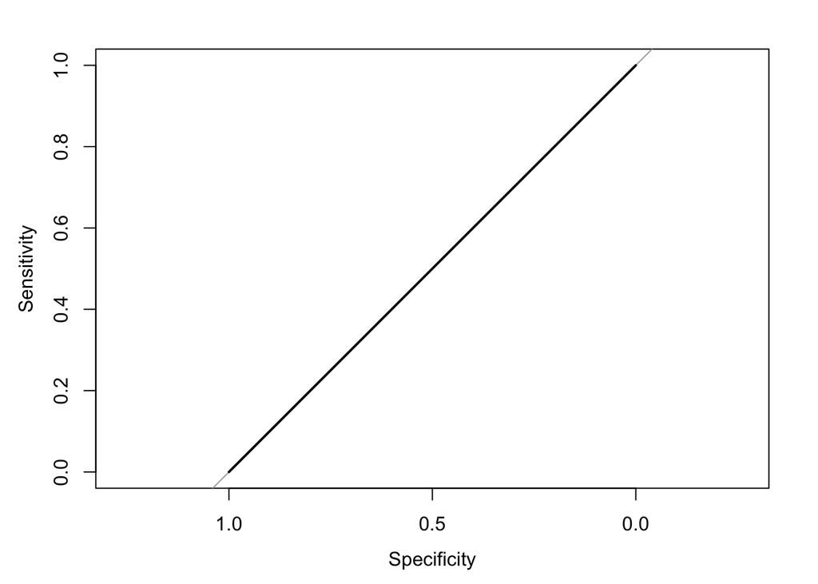

```r
plot(roc_m1, axes.legacy = T)
```

Then cross-validate the logistic regression and re-calculate performance on the testing folds. N.B. The cross-validation functions you already have should be tweaked: you need to calculate these new performance measures. Alternatively, the groupdata2 and cvms package created by Ludvig are an easy solution.

N.B. the predict() function generates log odds (the full scale between minus and plus infinity). Log odds > 0 indicates a choice of 1, below a choice of 0. N.N.B. you need to decide whether calculate performance on each single test fold or save all the prediction for test folds in one datase, so to calculate overall performance. N.N.N.B. Now you have two levels of structure: subject and study. Should this impact your cross-validation? N.N.N.N.B. A more advanced solution could rely on the tidymodels set of packages (warning: Time-consuming to learn as the documentation is sparse, but totally worth it)

```r
#SIGRID
############################## Cross validation function ##########################

cross_valid <- function(dataset, k, mod){
  #partioning data, balanced by diagnosis
  df1 <- groupdata2::fold(dataset, k = k, cat_col = "Diagnosis", id_col = "New_id") %>% arrange(.folds)

#Defining output variables
AUC <- rep(NA,k)
Accuracy <- rep(NA,k)
Sensitivity <- rep(NA,k)
Specificity <- rep(NA,k)
PPV <- rep(NA,k)
NPV <- rep(NA,k)
Intercept <- rep(NA,k)
Slope <- rep(NA,k)

for (i in seq.int(1,k)){
  train_set = subset(df1, .folds != i)
  validation_set = subset(df1, .folds == i)
  model = glmer(mod, family = "binomial", train_set)
  model_result = summary(model)

  #Getting predictions in probabilities for test data and train data
  #Test
  validation_set <- validation_set %>%
    mutate(
    prediction = logit2prob(predict(model, validation_set, allow.new.levels = T)),
    prediction = ifelse(prediction > 0.5, "Schizophrenia", "Control"),
    prediction = as.factor(prediction)
  )

  #Getting different performance measures
  cm <- confusionMatrix(data = validation_set$prediction, reference = validation_set$Diagnosis, positive = "Schizophrenia")

  #making ROC-curves for both train and test data
  rocCurve = roc(response = validation_set$Diagnosis, predictor = as.numeric(validation_set$prediction))

  #Adding values to the variables
  Accuracy[i] <- cm$overall[[1]] #Accurancy
  Sensitivity[i] <- cm$byClass[[1]] #Sensitivity
  Specificity[i] <- cm$byClass[[2]] #Specificity
  PPV[i] <- cm$byClass[[3]] #PPV
  NPV[i] <- cm$byClass[[4]] #NPV
  AUC[i] <- auc(rocCurve)
  Intercept[i] <- model_result$coefficients[1]
  Slope[i] <- model_result$coefficients[2]
}
result = data.frame(Accuracy, Sensitivity, Specificity, PPV, NPV, AUC, Intercept, Slope)
  return (result)
}
```

```r
# ANDERS
#Using the cross-validation function

# writing the model formula to use in the cv function
m1_cv <- Diagnosis ~ pitch_variability + (1|New_id) + (1|Language) + (1|Study)

# running the cross validation and saving it in a table
cv_results <- cross_valid(df_train, 10, m1_cv)
```

```
## boundary (singular) fit: see ?isSingular
```

```
## Warning in confusionMatrix.default(data = validation_set$prediction,
## reference = validation_set$Diagnosis, : Levels are not in the same order
## for reference and data. Refactoring data to match.
```

[output not shown]

[output not shown]

[output not shown]

[output not shown]

[output not shown]

[output not shown]

[output not shown]

[output not shown]

```r
cv_results
```

```
##     Accuracy Sensitivity Specificity       PPV       NPV AUC Intercept
## 1  0.5310078           0           1       NaN 0.5310078 0.5 -14.37424
## 2  0.5261324           0           1       NaN 0.5261324 0.5 -13.87192
## 3  0.6625767           0           1       NaN 0.6625767 0.5 -13.83042
## 4  0.5135135           0           1       NaN 0.5135135 0.5 -14.44415
## 5  0.4795539           1           0 0.4795539       NaN 0.5  13.36182
## 6  0.5078534           0           1       NaN 0.5078534 0.5 -14.48319
## 7  0.5390335           0           1       NaN 0.5390335 0.5 -13.98419
## 8  0.5281899           0           1       NaN 0.5281899 0.5 -14.12125
## 9  0.5201613           0           1       NaN 0.5201613 0.5 -13.90081
## 10 0.5938865           0           1       NaN 0.5938865 0.5 -14.66694
##          Slope
## 1  -0.17738825
## 2  -0.11583203
## 3  -0.11564834
## 4  -0.11874502
## 5  -0.16916264
## 6  -0.11082545
## 7  -0.09868226
## 8  -0.09986005
## 9  -0.11179391
## 10 -0.10216499
```

```r
############################### MAKING FINAL MODEL ######################################
#GUSTAV
#averaging the intercept and beta estimates
intercept <- mean(cv_results$Intercept)
slope <- mean(cv_results$Slope)

# inserting the averaged intercept and slope in m1
m1@beta[1] <- intercept
m1@beta[2] <- slope

summary(m1)
```

```
## Generalized linear mixed model fit by maximum likelihood (Laplace
##   Approximation) [glmerMod]
##  Family: binomial  ( logit )
## Formula: Diagnosis ~ pitch_variability + (1 | New_id) + (1 | Language) +
##     (1 | Study)
##    Data: df_train
##
##      AIC      BIC   logLik deviance df.resid
##    364.0    393.3   -177.0    354.0     2623
##
## Scaled residuals:
##       Min        1Q    Median        3Q       Max
## -0.000987 -0.000950 -0.000889  0.020704  0.038347
##
## Random effects:
##  Groups   Name        Variance Std.Dev.
##  New_id   (Intercept) 4922     70.16
##  Study    (Intercept)    0      0.00
##  Language (Intercept)    0      0.00
## Number of obs: 2628, groups:  New_id, 235; Study, 6; Language, 2
##
## Fixed effects:
##                   Estimate Std. Error z value Pr(>|z|)
## (Intercept)       -11.4315     0.9562 -11.955   <2e-16 ***
## pitch_variability  -0.1220     0.4858  -0.251    0.802
## ---
## Signif. codes:  0 '***' 0.001 '**' 0.01 '*' 0.05 '.' 0.1 ' ' 1
##
## Correlation of Fixed Effects:
##             (Intr)
## ptch_vrblty 0.002
## optimizer (Nelder_Mead) convergence code: 0 (OK)
## boundary (singular) fit: see ?isSingular
```

```r
################### TESTING THE MODEL ON THE TEST DATA ############################
#SIGRID
df_test <- df_test %>%
  mutate(
    pred = logit2prob(predict(m1, df_test, allow.new.levels = T)),
    pred = ifelse(pred > 0.5, "Schizophrenia", "Control"),
    pred = as.factor(pred)
)

# getting performance measures
confusionMatrix(data = df_test$pred, reference = df_test$Diagnosis, positive = 'Schizophrenia')
```

```
## Confusion Matrix and Statistics
##
##                Reference
## Prediction      Control Schizophrenia
##   Control           358           336
##   Schizophrenia       0             0
##
##                Accuracy : 0.5159
##                  95% CI : (0.4779, 0.5536)
##     No Information Rate : 0.5159
##     P-Value [Acc > NIR] : 0.5153
##
##                   Kappa : 0
##
##  Mcnemar's Test P-Value : <2e-16
##
##             Sensitivity : 0.0000
##             Specificity : 1.0000
##          Pos Pred Value :    NaN
##          Neg Pred Value : 0.5159
##              Prevalence : 0.4841
##          Detection Rate : 0.0000
##    Detection Prevalence : 0.0000
##       Balanced Accuracy : 0.5000
##
##        'Positive' Class : Schizophrenia
##
```

```r
# ROC-curve
rocCurve <-  roc(response = df_test$Diagnosis, predictor = as.numeric(df_test$pred))
auc(rocCurve)
```

```
## Area under the curve: 0.5
```

```r
ci(rocCurve)
```

```
## 95% CI: 0.5-0.5 (DeLong)
```

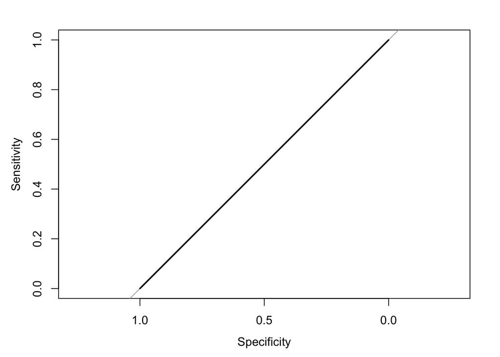

```r
plot(rocCurve, axes.legacy = T)
```